# Homework Assignment week 3

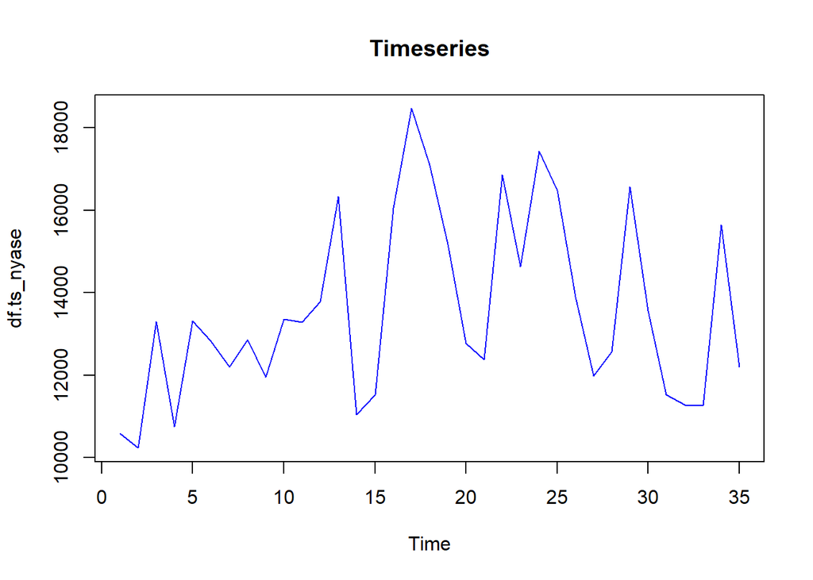

```r
plot.ts(df.ts_nyase,main="Timeseries", col="blue") #every five months
```

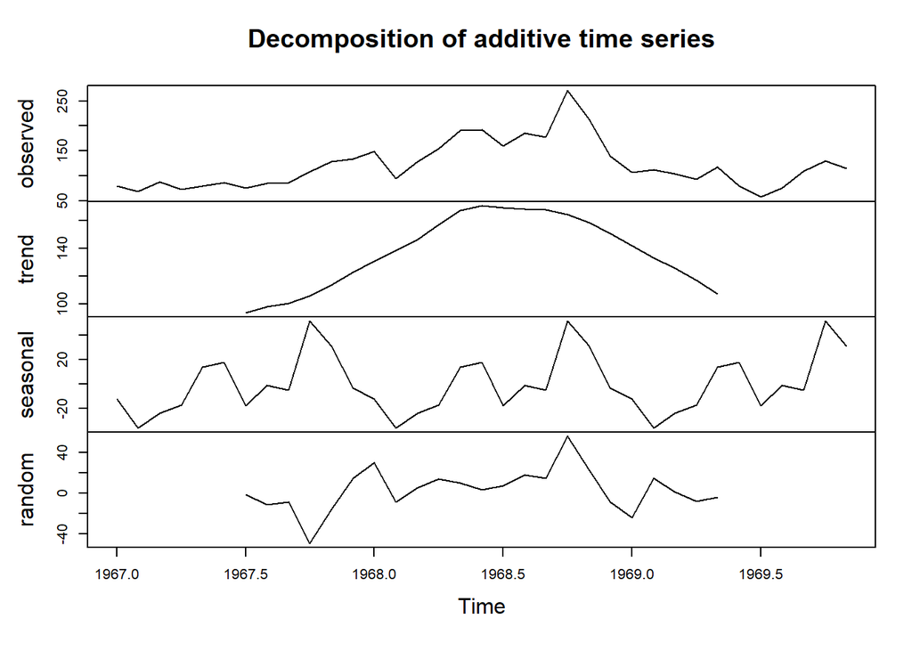

```r
# We can “decompose” the time series — which in this case means separating out the 4 main components that make up the time series:
# trend: the long-term trends in the data
# seasonal: the repeated seasonal signal adder
# random: the “left-over” components that aren’t expected from the seasonality or trend components.
# observed: the real values in the data

df_decompose_bse <- decompose(df.ts_bse, type = "additive")
#df_decompose_nyase <- decompose(df.ts_nyase, type = "additive")

# Notice how I chose additive instead of multiplicative since there is no exponential increase in the amplitudes over time.

plot(df_decompose_bse)
```

```r
#plot(df_decompose_nyase)
```

```r
# HoltWinters
# Holt-Winters forecasting is a way to model and predict the behavior of a sequence of values over time—a time series.

tmp1 <- HoltWinters(df.ts_bse)

attributes(tmp1)
```

```
## $names
## [1] "fitted"       "x"            "alpha"        "beta"         "gamma"
## [6] "coefficients" "seasonal"     "SSE"          "call"
##
## $class
## [1] "HoltWinters"
```

```r
#tmp2 <- HoltWinters(df.ts_nyase)
#attributes((tmp2))
```

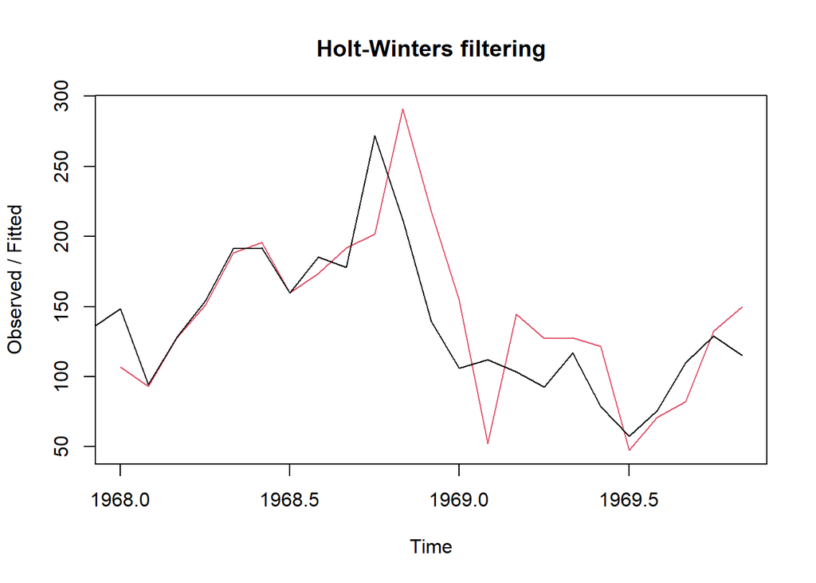

```r
plot(tmp1)
```

```r
#plot(tmp2)
```

```r
# black line is the actual data and red line is the HoltWinters..
# We can see that the data fits for sometime and then it deviates little bit from the actual data...


tmp_f <- forecast(tmp1)
attributes(tmp_f)
```

```
## $names
##  [1] "method"    "model"     "level"     "mean"      "lower"     "upper"
##  [7] "x"         "series"    "fitted"    "residuals"
##
## $class
## [1] "forecast"
```

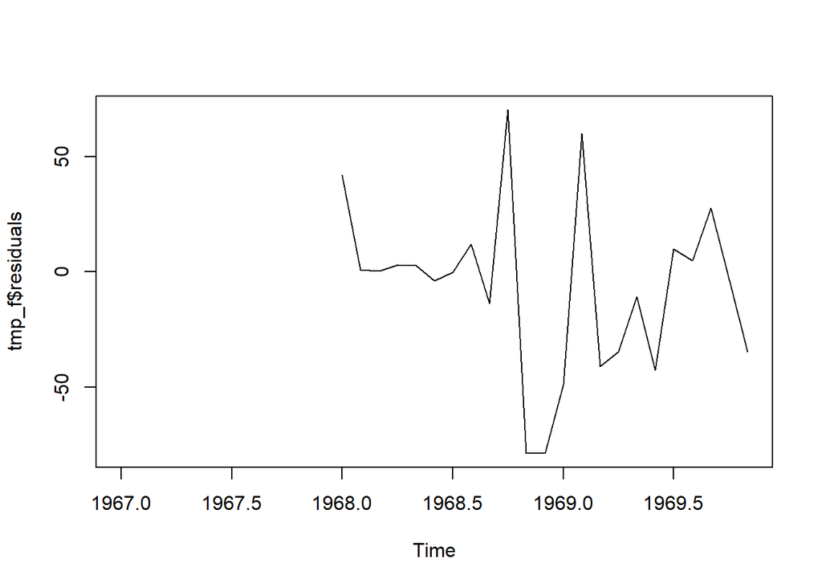

```r
plot(tmp_f$residuals)
```

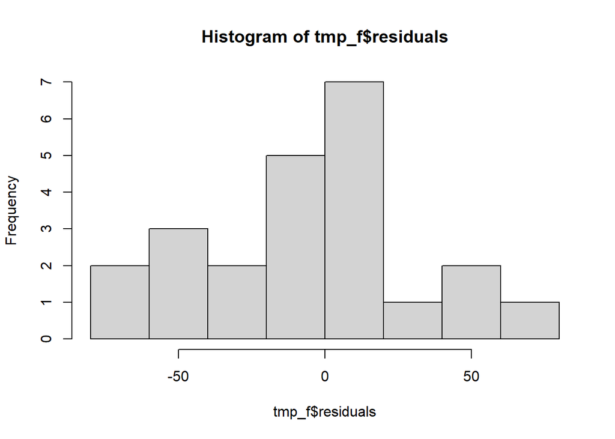

```r
plot(hist(tmp_f$residuals))
```

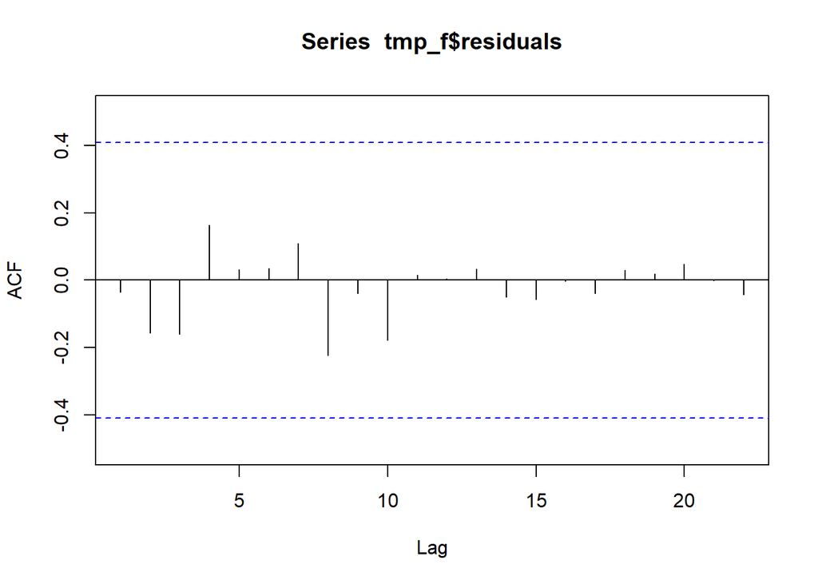

```r
Acf(tmp_f$residuals)
```

```r
accuracy(tmp_f)
```

```
##                    ME    RMSE      MAE       MPE     MAPE      MASE        ACF1
## Training set -6.82411 37.4424 27.12859 -6.724361 21.27763 0.3433243 -0.03517022
```

Question3_Data Collection Methodology (2 points). State how the data is collected, by whom, how often, etc.  
**Data collection in stock exchanges like NYSE (New York Stock Exchange) and BSE (Boston Stock Exchange) involves the meticulous recording of trading activity and market surveillance. The core of this data is the order book, which records buy and sell orders for securities, including price, quantity, and time. When orders match, trade data is recorded, capturing details of trade price, quantity, and execution time. Stock exchanges provide access to this data through data providers, facilitating real-time access to trading activity and historical data archives. Real-time data is available with minimal delay, often measured in milliseconds, while historical data is used for backtesting and analysis. Regulatory oversight requires exchanges to report trading activity to regulatory authorities, ensuring market integrity and adherence to securities laws. Market data fees are charged for access to this valuable information, and data is typically provided in standardized formats. The specifics of data collection may vary between exchanges, and each exchange operates under its own set of rules and regulations governing data collection and dissemination.**

Question4_Why did this data set intrigued me?  
**For financial analysts, investors, and researchers alike, a monthly dataset of dollar volume sales on the Boston Stock Exchange holds substantial interest. By providing in-depth assessments of trade activity, market movements, and liquidity, it provides a window into the dynamics of financial markets. Analysts are able to identify seasonal patterns, assess market efficiency, and assess the effects of significant financial events by monitoring variations in trading volumes over time. Historical analysis offers a window into the development of the exchange and larger market, while traders can gain useful insights for creating and testing trading methods. The dataset also helps regulatory authorities ensure market integrity and provides a platform for machine learning algorithms. To put it simply, this dataset is an essential tool for comprehending and managing the intricacies.I chose this dataset because it was a built in dataset and i wanted to get acclaimatized with the resources I have in R itself although there were many datasets online I decided to go with this because I wanted something to do with Stock Markets and when I saw the data I was sure to work on it. Additionally I have tried to do as many computations as I could by adding the concepts from Professor’s work in both the weeks and implement most scenarios**